# BayesDeep Tutorial

Xi Jiang

BayesDeep is an approach for reconstructing spatial transcriptomics data at the single-cell resolution by linking image and molecular profiles under the Bayesian framework.

# Installation

To utilize the BayesDeep function, ensure that the following packages are installed.

```r
library(ggplot2)
library(Rcpp)
library(RcppArmadillo)
library(RcppDist)
library(Matrix)
```

Load the functions used to run BayesDeep.

```r
source('R/BayesDeep_functions.R')
```

# Load Data

The current version of BayesDeep requires the spatial transcriptomics (ST) data and the corresponding image profiles:

ST data: * The gene expression count matrix **count**: $N\times P$ ($N$ - number of spots; $P$ - number of genes) * The location information matrix **T_spot**: $N\times 2$. It includes the x and y coordinate for each sample point.

Image profiles from nuclei identification method: * The location information matrix **T_cell**: $M\times 2$ ($M$ - number of cells). It includes the x and y coordinate for all identified cells. * The cell type information **Z_cell**: $M\times 1$. It includes the nuclei class for all identified cells. * The nucleus shape information matrix **X_cell**: $M\times L$. It includes all nucleus shape features for identified cells.

All these data should be stored in R matrix or vector format, with gene names as column names for the gene expression count matrix.

In the following section, we demonstrate the analysis using human breast cancer 10x Visium data as an example to illustrate the implementation of BayesDeep.

Data can be downloaded from ‘Data_for_BayesDeep’ folder on the Dropbox: https://www.dropbox.com/scl/fo/5wj49vf8561h5nl8mc4pu/h?rlkey=q1xssoiqnenq6ohaxrioflk40&dl=0

```r
# load data
load("Data_for_BayesDeep/10x_breast_cancer_data_for_BayesDeep.RData")
```

The human breast cancer 10x Visium dataset comprises $2,518$ sample points and $17,943$ genes. For the histology image, the HD staining model identified $156,115$ nuclei, categorizing them into seven cell types and capturing 10 nucleus shape features.

# Data Processing

Before running BayesDeep to get the gene expression at single-cell resolution, there are several steps to prepare the data.

## Generate spot-cell spatial relationship matrix $G$

For this data, the diameter of a spot in the full-resolution histology image is approximately $189$ pixels. To establish spatial relationships, we calculate the distance between each spot and each cell and construct the spatial relationship matrix $G$ by determining whether a cell belongs to a particular spot.

```r
# generate G
G <- get.spatial.matrix(T_spot, T_cell, spot_diameter = 189)
```

```
## [1] "0% has been done"
## [1] "10% has been done"
## [1] "20% has been done"
## [1] "30% has been done"
## [1] "40% has been done"
## [1] "50% has been done"
## [1] "60% has been done"
## [1] "70% has been done"
## [1] "80% has been done"
## [1] "90% has been done"
## [1] "100% has been done"
```

## Process covariates $X$

We process the nuclei identification results obtained from the HD staining model to generate covariates for BayesDeep. In the case of cell type information, we transform it into dummy variables. As for the numerical shape features, we apply the ‘scale’ function to normalize and standardize them.

```r
Z <- get.dummy(Z_cell)
X_cell <- scale(X_cell)

X <- cbind(Z, X_cell)
```

## Generate library size factor $s$

Finally, we compute the library size factor $s$ using total-sum-scaling. $s$ is proportional to the summation of gene expression counts for spots across all genes.

```r
s <- get.size.factor(count)
```

# Run BayesDeep

As an illustrative example, we choose the gene *MUCL1* to demonstrate the process of running BayesDeep. We plot the gene expression at the spot resolution.

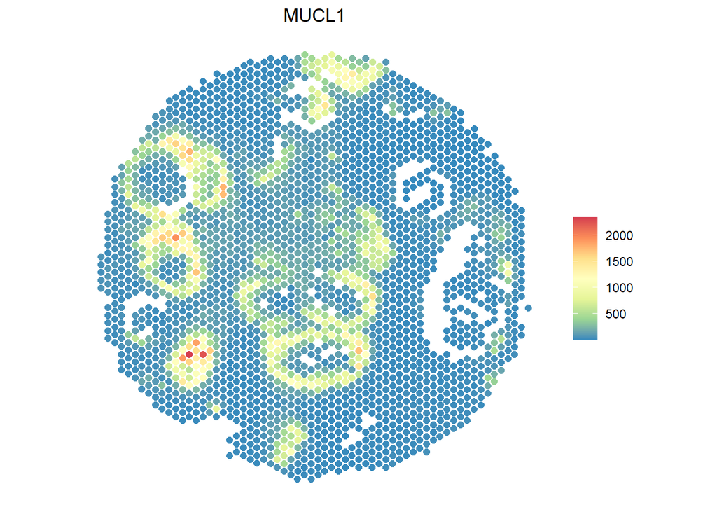

```r
gene <- 'MUCL1'
y <- count[, gene]

plot.st(y, T_spot, point_size = 2, gene_name = gene)
```

*run.BayesDeep* function requires the expression counts for the specific gene $y$, covariate matrix $X$, spot-cell spatial relationship matrix $G$, and the estimated library size factor $s$ as input.

```r
res <- run.BayesDeep(y, X, G, s)
```

```
## 10% has been done
## 20% has been done
## 30% has been done
## 40% has been done
## 50% has been done
## 60% has been done
## 70% has been done
## 80% has been done
## 90% has been done
```

The *run.BayesDeep* function outputs: - the estimated covariate coefficients $\beta$, which represents the association between the single-cell-resolution gene expression and the covariates; - the predicted gene expression at single-cell resolution $\theta$.

```r
beta <- res$beta
print(beta)
```

```
##            stroma          necrosis        lymphocyte             blood
##        4.54281554        4.76822815        3.64071541        4.05497909
##             tumor ductal epithelium        macrophage              area
##        5.88480440        5.80750717       -0.00354526        0.00000000
##       convex_area      eccentricity            extent       filled_area
##        0.00000000        0.00000000        0.00000000       -0.14543268
## major_axis_length minor_axis_length       orientation         perimeter
##        0.00000000        0.00000000        0.00000000        0.32558775
##          solidity
##        0.71768803
```

We plot the reconstructed gene expression at the single-cell resolution.

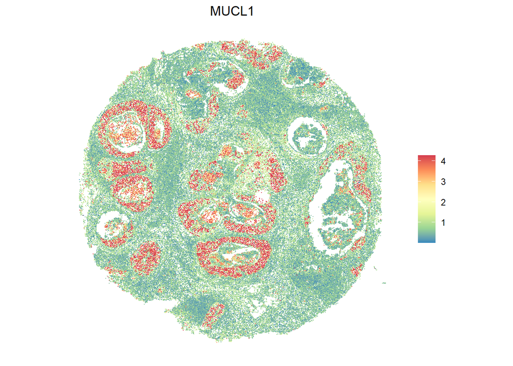

```r
expr <- res$expr
plot.st(expr, T_cell, point_size = 0.1, gene_name = gene)
```